# StatFindings2

Harry

11/26/2017

[10 data insights]

0. setup
1. Defualt and age

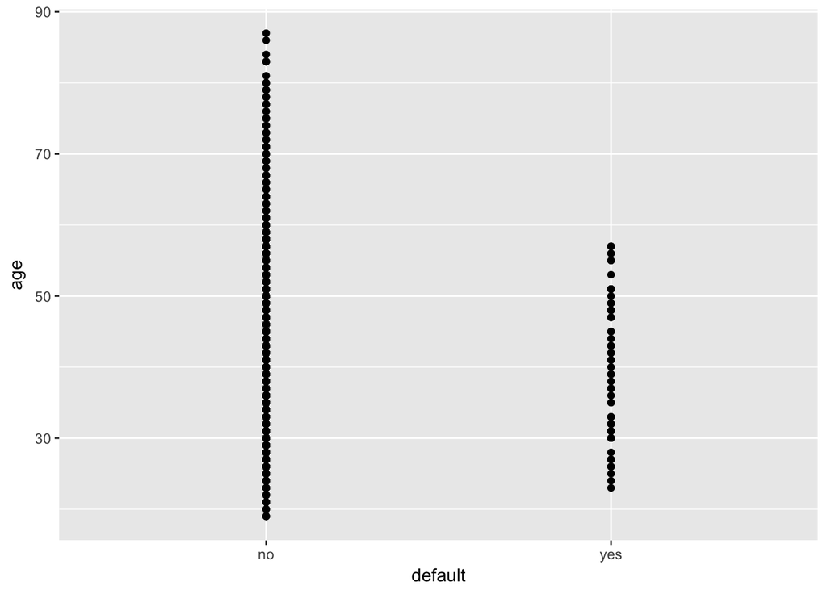

```r
ggplot(bank, aes(default, age)) + geom_point()
```

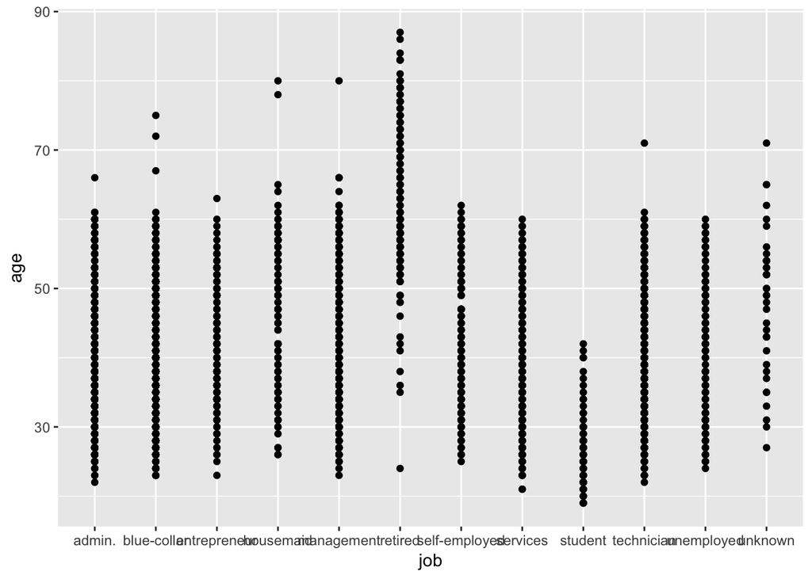

```r
ggplot(bank, aes(job, age)) + geom_point()
```

- The group of retired and the group of students has a skewed age distribution to old and young ages, for each.
- Besides, we can observe that Management, Housemaid, Bluecollar groups sometimes work even after their 70’s.

3.Different duration depending on age and by contact group

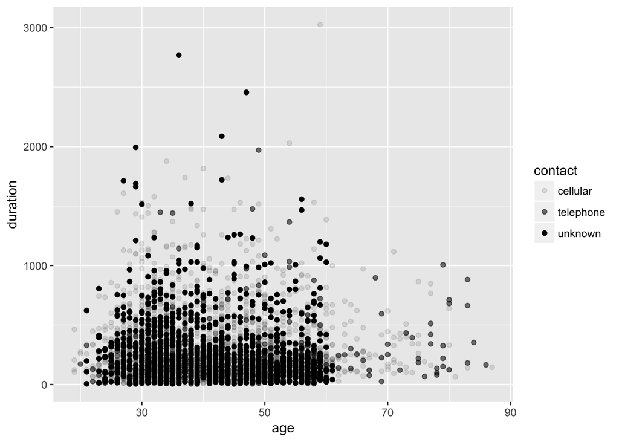

```r
ggplot(bank) + geom_point(aes(age, duration, alpha = contact))
```

- Telephone using group has shorter duration compared to cellular using group and unknown group.

4.Density of age group depending on different job category

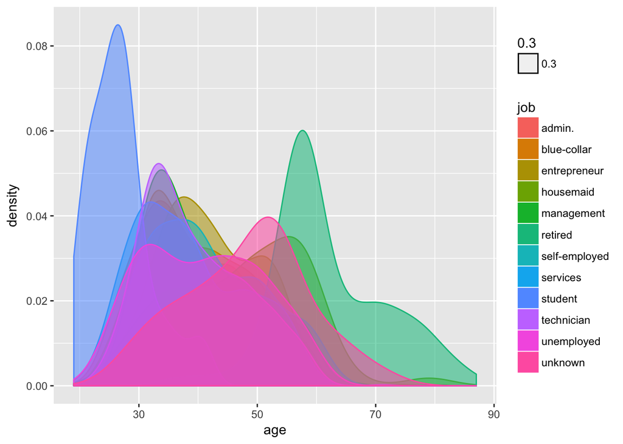

```r
ggplot(bank, aes(age, color=job, fill=job, alpha = 0.3)) + geom_density()
```

- Student and retired group has most of population age at 20’s and 60’s for each.
- Many groups including technician, services and self-employed have population age mainly between 30’s and 40’s.
5. Sort job by mean age and education

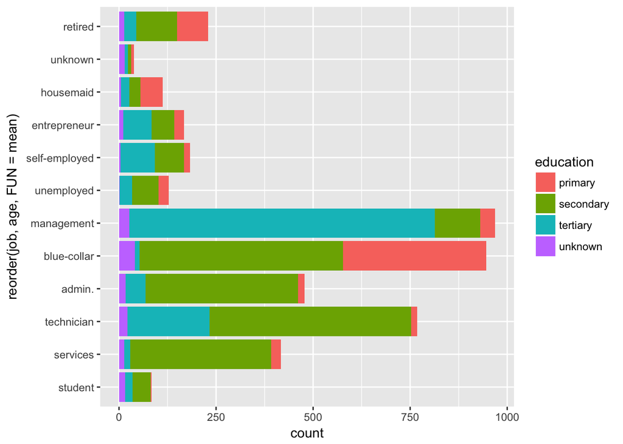

```r
ggplot(data = bank, mapping=aes(x=reorder(job, age, FUN=mean), fill=education))+
  geom_bar()+coord_flip()
```

- Blue-collar group has the laregest portion of people who got primary education whereas management group has the largest portion of people who got tertiary education.
6. Box plot of balance depending on age group and employment group

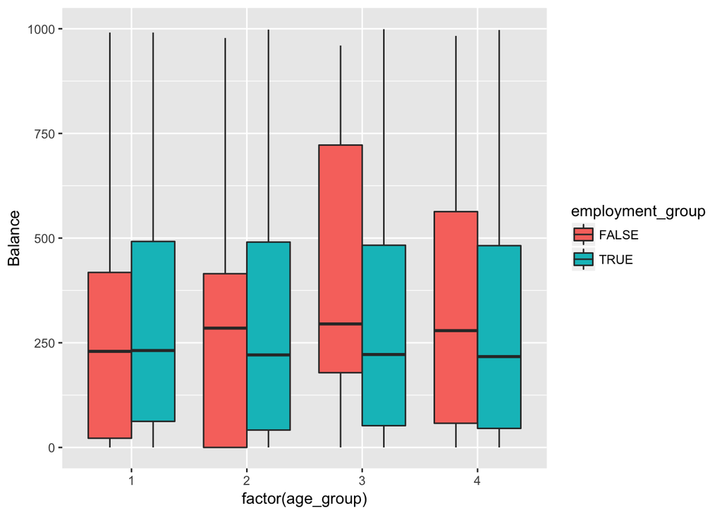

```r
group_by(bank , age_group = ntile(age, 4)) %>%
  mutate(., employment_group = !(job %in% c("unemployed", "student", "retired", "unknown"))) %>%
  select(., age_group, employment_group, balance) %>%
  ggplot(., aes(x=factor(age_group), y = balance, fill = employment_group))+
  geom_boxplot()+
  scale_y_continuous(name = "Balance",
                     limits=c(0, 1000))
```

- In case of 3rd quarter age group, unemployed group has more balance than unemployeed group.
7. Count of month

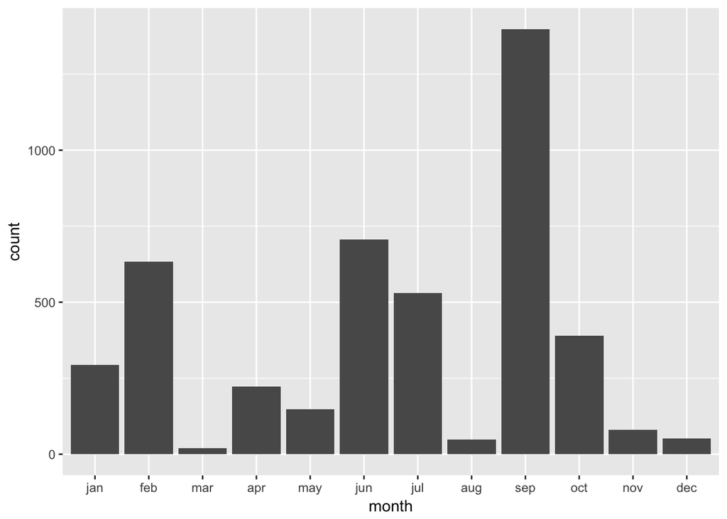

```r
df = bank
levels(df$month) <- levels(df$month)[c(5,4,8,1,9,7,6,2,12,11,10,3)]
ggplot(df, aes(x=month)) +
  geom_bar()
```

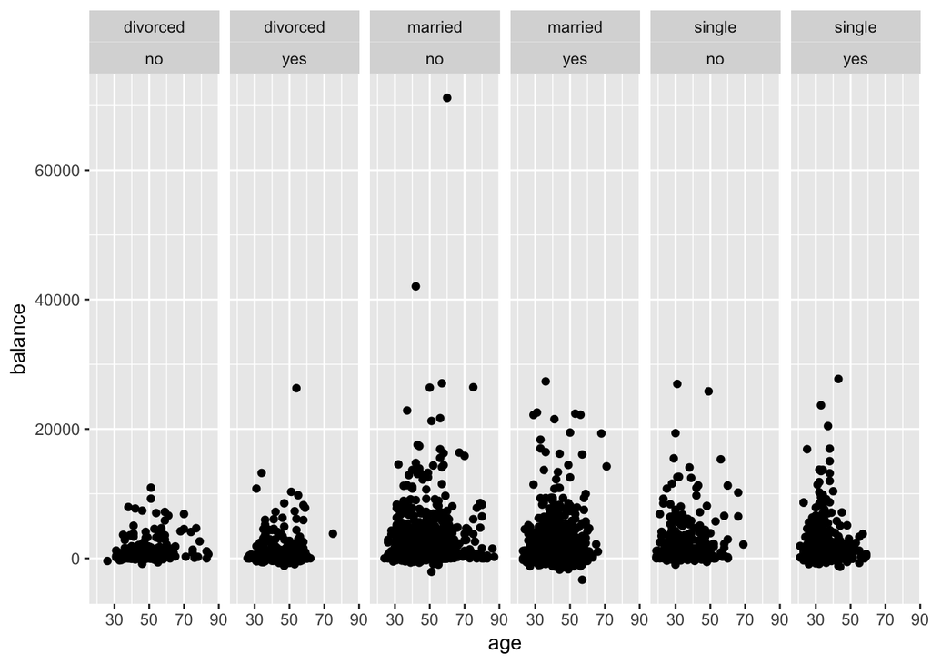

```r
ggplot(data = bank) +
geom_point(mapping = aes(x = age, y = balance)) +
facet_wrap(marital ~ housing, nrow = 1)
```

- Divorced and no housing group has lowest balance in average, compared to other groups.
9. Age group and contact methods

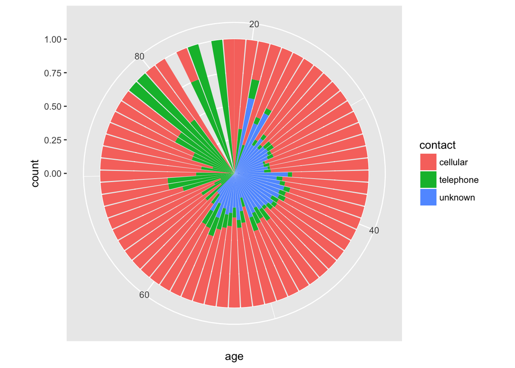

```r
ggplot(bank) +
geom_bar(mapping = aes(x = age, fill = contact), position = "fill") +
coord_polar()
```

- Older age group(over 70’s)tends to use more telephone rather than younger age group.
10. Loan and education

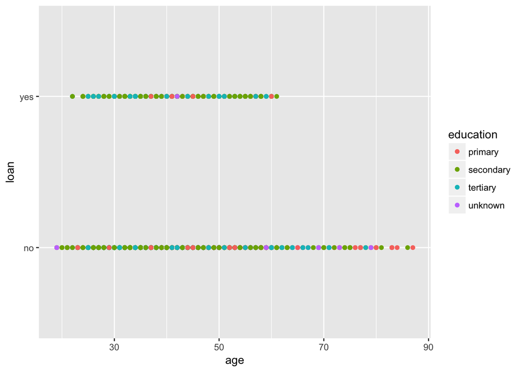

```r
ggplot(bank, aes(age, loan, color = education)) + geom_point()
```